# Parkinson’s Disease (PD)

It is a degenerative neurological disorder marked by decreased dopamine levels in the brain. It manifests itself through a deterioration of movement, including the presence of tremors and stiffness. There is commonly a marked effect on speech, including dysarthria (difficulty articulating sounds), hypophonia (lowered volume), and monotone (reduced pitch range). Additionally, cognitive impairments and changes in mood can occur, and risk of dementia is increased.

Traditional diagnosis of Parkinson’s Disease involves a clinician taking a neurological history of the patient and observing motor skills in various situations. Since there is no definitive laboratory test to diagnose PD, diagnosis is often difficult, particularly in the early stages when motor effects are not yet severe. Monitoring progression of the disease over time requires repeated clinic visits by the patient. An effective screening process, particularly one that doesn’t require a clinic visit, would be beneficial. Since PD patients exhibit characteristic vocal features, voice recordings are a useful and non-invasive tool for diagnosis. If machine learning algorithms could be applied to a voice recording dataset to accurately diagnosis PD, this would be an effective screening step prior to an appointment with a clinician. The data & attributes information for this project is available at https://archive.ics.uci.edu/ml/machine-learning-databases/parkinsons/The data consists of those diagnosed with Parkinson Disease and those who do not.

**Steps to be followed:**

1. Load the dataset
2. It is always a good practice to eye-ball raw data to get a feel of the data in terms of number of structure of the file, number of attributes, types of attributes and a general idea of likely challenges in the dataset. (2.5 points)
3. Using univariate & bivariate analysis to check the individual attributes for their basic statistic such as central values, spread, tails etc. What are your observations? (15 points)
4. Split the dataset into training and test set in the ratio of 70:30 (Training:Test).
5. Create the model using “entropy” method of reducing the entropy and fit it to training data. (5 points)
6. Test the model on test data and what is the accuracy achieved. Capture the predicted values and do a crosstab. (7.5 points)
7. Use regularization parameters of max_depth, min_sample_leaf to recreate the model. What is the impact on the model accuracy? How does regularization help? (20 points)
8. Next implement the decision tree using Random Forest. What is the optimal number of trees that gives the best result? (10 points)

```python
import numpy as np
import pandas as pd

# To enable plotting graphs in Jupyter notebook
import matplotlib.pyplot as plt

#importing seaborn for statistical plots
import seaborn as sns

# calculate accuracy measures and confusion matrix
from sklearn import metrics

# To enable plotting graphs in Jupyter notebook
%matplotlib inline
import warnings
warnings.filterwarnings('ignore')

from sklearn.ensemble import RandomForestClassifier, BaggingClassifier, AdaBoostClassifier
from scipy.stats import zscore
from scipy.stats import stats
from sklearn.metrics import roc_curve, auc, accuracy_score, confusion_matrix

from sklearn.model_selection import cross_validate, ShuffleSplit, GridSearchCV
from sklearn import ensemble, naive_bayes, svm, tree, discriminant_analysis, neighbors, feature_selection
from scipy.stats import zscore
```

# 1. Load the dataset

```python
park_data = pd.read_csv('parkinsons.data')
```

# 2. Analysis of raw data to get a feel of the data in terms of number of structure of the file, number of attributes, types of attributes and a general idea of likely challenges in the dataset. (2.5 points)

```python
park_data.head(10)
```

|  | name | MDVP:Fo(Hz) | MDVP:Fhi(Hz) | MDVP:Flo(Hz) | MDVP:Jitter(%) | MDVP:Jitter(Abs) | MDVP:RAP | MDVP:PPQ | Jitter:DDP | MDVP:Shimmer | ... | Shimmer:DDA | NHR | HNR | status | RPDE | DFA | spread1 | spread2 | D2 | PPE |
| --- | --- | --- | --- | --- | --- | --- | --- | --- | --- | --- | --- | --- | --- | --- | --- | --- | --- | --- | --- | --- | --- |
| 0 | phon_R01_S01_1 | 119.992 | 157.302 | 74.997 | 0.00784 | 0.00007 | 0.00370 | 0.00554 | 0.01109 | 0.04374 | ... | 0.06545 | 0.02211 | 21.033 | 1 | 0.414783 | 0.815285 | -4.813031 | 0.266482 | 2.301442 | 0.284654 |
| 1 | phon_R01_S01_2 | 122.400 | 148.650 | 113.819 | 0.00968 | 0.00008 | 0.00465 | 0.00696 | 0.01394 | 0.06134 | ... | 0.09403 | 0.01929 | 19.085 | 1 | 0.458359 | 0.819521 | -4.075192 | 0.335590 | 2.486855 | 0.368674 |
| 2 | phon_R01_S01_3 | 116.682 | 131.111 | 111.555 | 0.01050 | 0.00009 | 0.00544 | 0.00781 | 0.01633 | 0.05233 | ... | 0.08270 | 0.01309 | 20.651 | 1 | 0.429895 | 0.825288 | -4.443179 | 0.311173 | 2.342259 | 0.332634 |
| 3 | phon_R01_S01_4 | 116.676 | 137.871 | 111.366 | 0.00997 | 0.00009 | 0.00502 | 0.00698 | 0.01505 | 0.05492 | ... | 0.08771 | 0.01353 | 20.644 | 1 | 0.434969 | 0.819235 | -4.117501 | 0.334147 | 2.405554 | 0.368975 |
| 4 | phon_R01_S01_5 | 116.014 | 141.781 | 110.655 | 0.01284 | 0.00011 | 0.00655 | 0.00908 | 0.01966 | 0.06425 | ... | 0.10470 | 0.01767 | 19.649 | 1 | 0.417356 | 0.823484 | -3.747787 | 0.234513 | 2.332180 | 0.410335 |
| 5 | phon_R01_S01_6 | 120.552 | 131.162 | 113.787 | 0.00968 | 0.00008 | 0.00463 | 0.00750 | 0.01388 | 0.04701 | ... | 0.06985 | 0.01222 | 21.378 | 1 | 0.415564 | 0.825069 | -4.242867 | 0.299111 | 2.187560 | 0.357775 |
| 6 | phon_R01_S02_1 | 120.267 | 137.244 | 114.820 | 0.00333 | 0.00003 | 0.00155 | 0.00202 | 0.00466 | 0.01608 | ... | 0.02337 | 0.00607 | 24.886 | 1 | 0.596040 | 0.764112 | -5.634322 | 0.257682 | 1.854785 | 0.211756 |
| 7 | phon_R01_S02_2 | 107.332 | 113.840 | 104.315 | 0.00290 | 0.00003 | 0.00144 | 0.00182 | 0.00431 | 0.01567 | ... | 0.02487 | 0.00344 | 26.892 | 1 | 0.637420 | 0.763262 | -6.167603 | 0.183721 | 2.064693 | 0.163755 |
| 8 | phon_R01_S02_3 | 95.730 | 132.068 | 91.754 | 0.00551 | 0.00006 | 0.00293 | 0.00332 | 0.00880 | 0.02093 | ... | 0.03218 | 0.01070 | 21.812 | 1 | 0.615551 | 0.773587 | -5.498678 | 0.327769 | 2.322511 | 0.231571 |
| 9 | phon_R01_S02_4 | 95.056 | 120.103 | 91.226 | 0.00532 | 0.00006 | 0.00268 | 0.00332 | 0.00803 | 0.02838 | ... | 0.04324 | 0.01022 | 21.862 | 1 | 0.547037 | 0.798463 | -5.011879 | 0.325996 | 2.432792 | 0.271362 |

10 rows × 24 columns

```python
park_data.tail()
```

|  | name | MDVP:Fo(Hz) | MDVP:Fhi(Hz) | MDVP:Flo(Hz) | MDVP:Jitter(%) | MDVP:Jitter(Abs) | MDVP:RAP | MDVP:PPQ | Jitter:DDP | MDVP:Shimmer | ... | Shimmer:DDA | NHR | HNR | status | RPDE | DFA | spread1 | spread2 | D2 | PPE |
| --- | --- | --- | --- | --- | --- | --- | --- | --- | --- | --- | --- | --- | --- | --- | --- | --- | --- | --- | --- | --- | --- |
| 190 | phon_R01_S50_2 | 174.188 | 230.978 | 94.261 | 0.00459 | 0.00003 | 0.00263 | 0.00259 | 0.00790 | 0.04087 | ... | 0.07008 | 0.02764 | 19.517 | 0 | 0.448439 | 0.657899 | -6.538586 | 0.121952 | 2.657476 | 0.133050 |
| 191 | phon_R01_S50_3 | 209.516 | 253.017 | 89.488 | 0.00564 | 0.00003 | 0.00331 | 0.00292 | 0.00994 | 0.02751 | ... | 0.04812 | 0.01810 | 19.147 | 0 | 0.431674 | 0.683244 | -6.195325 | 0.129303 | 2.784312 | 0.168895 |
| 192 | phon_R01_S50_4 | 174.688 | 240.005 | 74.287 | 0.01360 | 0.00008 | 0.00624 | 0.00564 | 0.01873 | 0.02308 | ... | 0.03804 | 0.10715 | 17.883 | 0 | 0.407567 | 0.655683 | -6.787197 | 0.158453 | 2.679772 | 0.131728 |
| 193 | phon_R01_S50_5 | 198.764 | 396.961 | 74.904 | 0.00740 | 0.00004 | 0.00370 | 0.00390 | 0.01109 | 0.02296 | ... | 0.03794 | 0.07223 | 19.020 | 0 | 0.451221 | 0.643956 | -6.744577 | 0.207454 | 2.138608 | 0.123306 |
| 194 | phon_R01_S50_6 | 214.289 | 260.277 | 77.973 | 0.00567 | 0.00003 | 0.00295 | 0.00317 | 0.00885 | 0.01884 | ... | 0.03078 | 0.04398 | 21.209 | 0 | 0.462803 | 0.664357 | -5.724056 | 0.190667 | 2.555477 | 0.148569 |

5 rows × 24 columns

```python
park_data.shape
```

```
(195, 24)
```

```python
park_data.info()
```

```
<class 'pandas.core.frame.DataFrame'>
RangeIndex: 195 entries, 0 to 194
Data columns (total 24 columns):
name                195 non-null object
MDVP:Fo(Hz)         195 non-null float64
MDVP:Fhi(Hz)        195 non-null float64
MDVP:Flo(Hz)        195 non-null float64
MDVP:Jitter(%)      195 non-null float64
MDVP:Jitter(Abs)    195 non-null float64
MDVP:RAP            195 non-null float64
MDVP:PPQ            195 non-null float64
Jitter:DDP          195 non-null float64
MDVP:Shimmer        195 non-null float64
MDVP:Shimmer(dB)    195 non-null float64
Shimmer:APQ3        195 non-null float64
Shimmer:APQ5        195 non-null float64
MDVP:APQ            195 non-null float64
Shimmer:DDA         195 non-null float64
NHR                 195 non-null float64
HNR                 195 non-null float64
status              195 non-null int64
RPDE                195 non-null float64
DFA                 195 non-null float64
spread1             195 non-null float64
spread2             195 non-null float64
D2                  195 non-null float64
PPE                 195 non-null float64
dtypes: float64(22), int64(1), object(1)
memory usage: 36.6+ KB
```

```python
park_data.describe().T
```

|  | count | mean | std | min | 25% | 50% | 75% | max |
| --- | --- | --- | --- | --- | --- | --- | --- | --- |
| MDVP:Fo(Hz) | 195.0 | 154.228641 | 41.390065 | 88.333000 | 117.572000 | 148.790000 | 182.769000 | 260.105000 |
| MDVP:Fhi(Hz) | 195.0 | 197.104918 | 91.491548 | 102.145000 | 134.862500 | 175.829000 | 224.205500 | 592.030000 |
| MDVP:Flo(Hz) | 195.0 | 116.324631 | 43.521413 | 65.476000 | 84.291000 | 104.315000 | 140.018500 | 239.170000 |
| MDVP:Jitter(%) | 195.0 | 0.006220 | 0.004848 | 0.001680 | 0.003460 | 0.004940 | 0.007365 | 0.033160 |
| MDVP:Jitter(Abs) | 195.0 | 0.000044 | 0.000035 | 0.000007 | 0.000020 | 0.000030 | 0.000060 | 0.000260 |
| MDVP:RAP | 195.0 | 0.003306 | 0.002968 | 0.000680 | 0.001660 | 0.002500 | 0.003835 | 0.021440 |
| MDVP:PPQ | 195.0 | 0.003446 | 0.002759 | 0.000920 | 0.001860 | 0.002690 | 0.003955 | 0.019580 |
| Jitter:DDP | 195.0 | 0.009920 | 0.008903 | 0.002040 | 0.004985 | 0.007490 | 0.011505 | 0.064330 |
| MDVP:Shimmer | 195.0 | 0.029709 | 0.018857 | 0.009540 | 0.016505 | 0.022970 | 0.037885 | 0.119080 |
| MDVP:Shimmer(dB) | 195.0 | 0.282251 | 0.194877 | 0.085000 | 0.148500 | 0.221000 | 0.350000 | 1.302000 |
| Shimmer:APQ3 | 195.0 | 0.015664 | 0.010153 | 0.004550 | 0.008245 | 0.012790 | 0.020265 | 0.056470 |
| Shimmer:APQ5 | 195.0 | 0.017878 | 0.012024 | 0.005700 | 0.009580 | 0.013470 | 0.022380 | 0.079400 |
| MDVP:APQ | 195.0 | 0.024081 | 0.016947 | 0.007190 | 0.013080 | 0.018260 | 0.029400 | 0.137780 |
| Shimmer:DDA | 195.0 | 0.046993 | 0.030459 | 0.013640 | 0.024735 | 0.038360 | 0.060795 | 0.169420 |
| NHR | 195.0 | 0.024847 | 0.040418 | 0.000650 | 0.005925 | 0.011660 | 0.025640 | 0.314820 |
| HNR | 195.0 | 21.885974 | 4.425764 | 8.441000 | 19.198000 | 22.085000 | 25.075500 | 33.047000 |
| status | 195.0 | 0.753846 | 0.431878 | 0.000000 | 1.000000 | 1.000000 | 1.000000 | 1.000000 |
| RPDE | 195.0 | 0.498536 | 0.103942 | 0.256570 | 0.421306 | 0.495954 | 0.587562 | 0.685151 |
| DFA | 195.0 | 0.718099 | 0.055336 | 0.574282 | 0.674758 | 0.722254 | 0.761881 | 0.825288 |
| spread1 | 195.0 | -5.684397 | 1.090208 | -7.964984 | -6.450096 | -5.720868 | -5.046192 | -2.434031 |
| spread2 | 195.0 | 0.226510 | 0.083406 | 0.006274 | 0.174351 | 0.218885 | 0.279234 | 0.450493 |
| D2 | 195.0 | 2.381826 | 0.382799 | 1.423287 | 2.099125 | 2.361532 | 2.636456 | 3.671155 |
| PPE | 195.0 | 0.206552 | 0.090119 | 0.044539 | 0.137451 | 0.194052 | 0.252980 | 0.527367 |

```python
park_data.isnull().sum()
```

```
name                0
MDVP:Fo(Hz)         0
MDVP:Fhi(Hz)        0
MDVP:Flo(Hz)        0
MDVP:Jitter(%)      0
MDVP:Jitter(Abs)    0
MDVP:RAP            0
MDVP:PPQ            0
Jitter:DDP          0
MDVP:Shimmer        0
MDVP:Shimmer(dB)    0
Shimmer:APQ3        0
Shimmer:APQ5        0
MDVP:APQ            0
Shimmer:DDA         0
NHR                 0
HNR                 0
status              0
RPDE                0
DFA                 0
spread1             0
spread2             0
D2                  0
PPE                 0
dtype: int64
```

# Observations:

# 3.Using univariate & bivariate analysis to check the individual attributes for their basic statistic such as central values, spread, tails etc. What are your observations? (15 points)

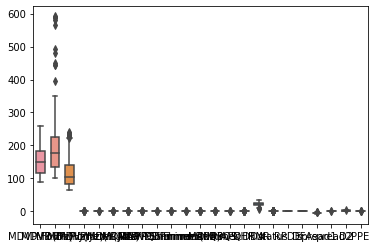

```python
import seaborn as sns
import matplotlib.pyplot as plt

sns.boxplot(data=park_data, width= 0.6)
```

**Rearranging columns, to have the column "status" at the end for making splitting easier.**

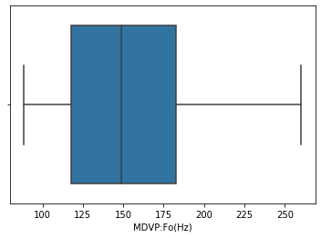

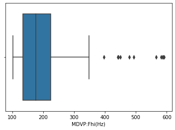

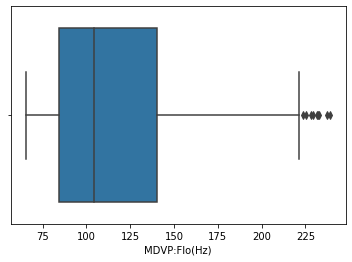

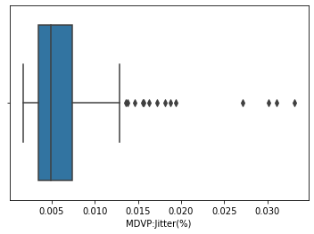

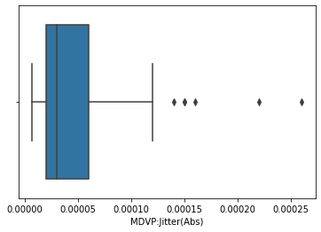

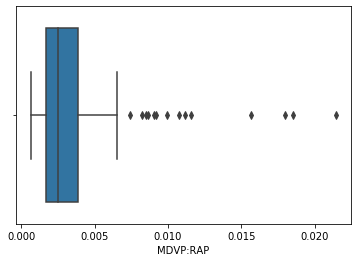

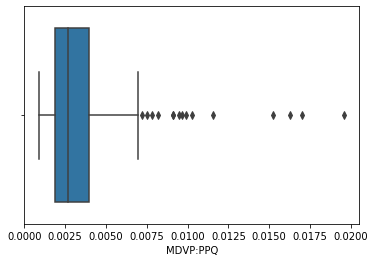

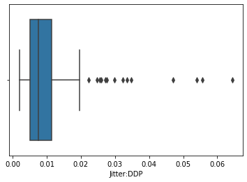

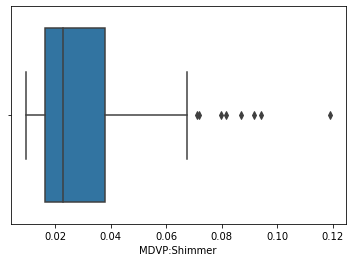

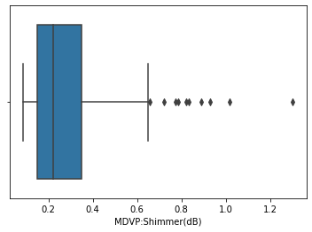

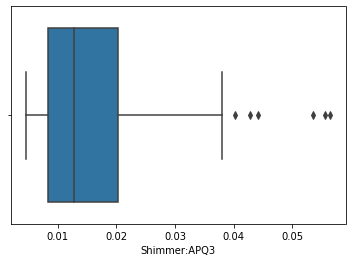

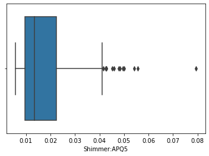

[10 more figures not shown]

```python
disc_cols = [col for col in park_data if col != 'status'] + ['status']
park_data = park_data[disc_cols]

for i, col in enumerate(disc_cols[1:-1]):
    plt.figure(i)
    sns.boxplot(park_data[col])
```

# Observation:

```python
Q1 = park_data.quantile(0.25)
Q3 = park_data.quantile(0.75)
IQR = Q3 - Q1
print("IQR for each attributes: \n")
((park_data < (Q1 - 1.5 * IQR)) | (park_data > (Q3 + 1.5 * IQR))).sum()
```

```
IQR for each attributes:
```

```
D2                   1
DFA                  0
HNR                  3
Jitter:DDP          14
MDVP:APQ            12
MDVP:Fhi(Hz)        11
MDVP:Flo(Hz)         9
MDVP:Fo(Hz)          0
MDVP:Jitter(%)      14
MDVP:Jitter(Abs)     6
MDVP:PPQ            15
MDVP:RAP            14
MDVP:Shimmer         8
MDVP:Shimmer(dB)    10
NHR                 19
PPE                  5
RPDE                 0
Shimmer:APQ3         6
Shimmer:APQ5        13
Shimmer:DDA          6
name                 0
spread1              4
spread2              2
status              48
dtype: int64
```

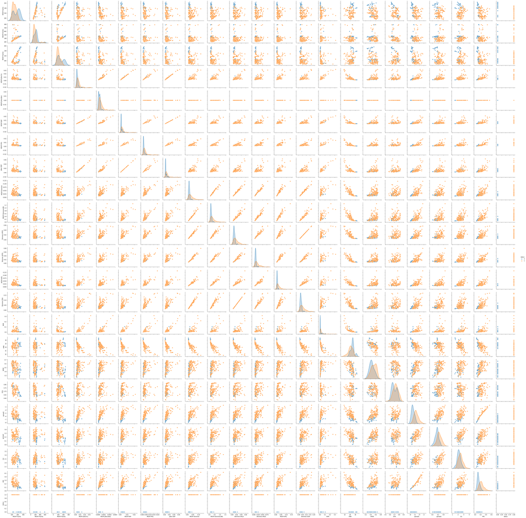

```python
import seaborn as sns
sns.pairplot(park_data, diag_kind='kde',hue = "status")
```

# Correlation analysis using heat map

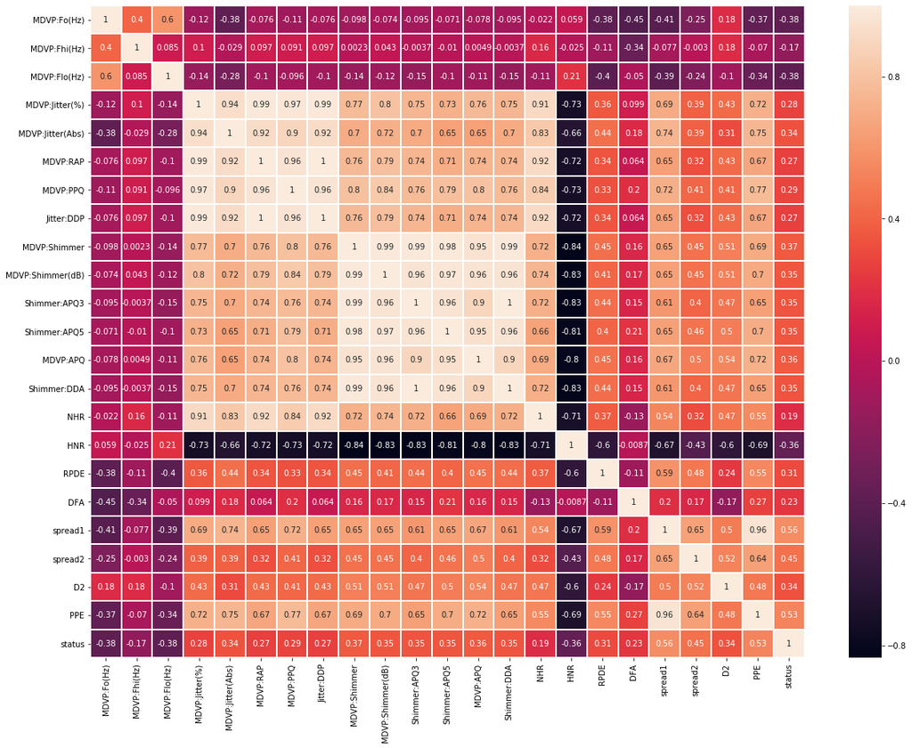

```python
plt.subplots(figsize=(20,15))
sns.heatmap(park_data.corr(), annot=True, linewidths=1)
```

# Observations

**spread1 and PPE have significant positive correlation with status.**

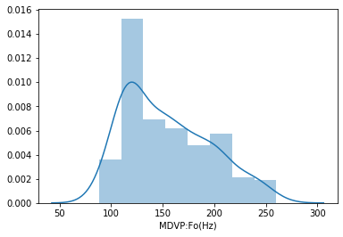

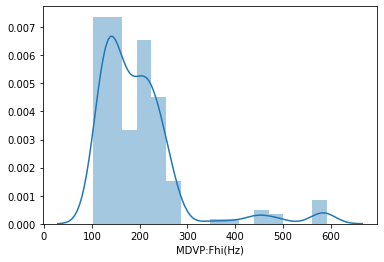

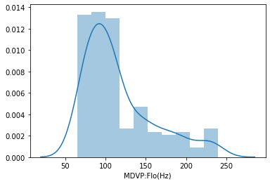

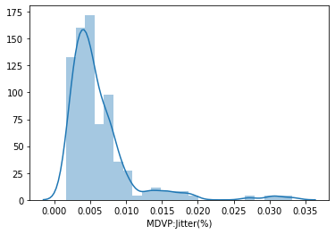

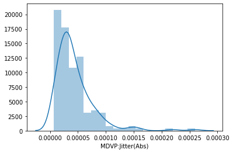

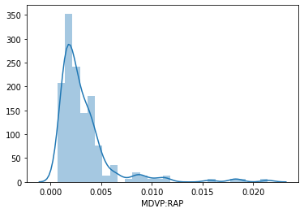

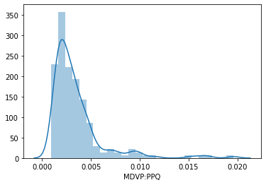

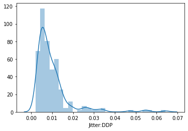

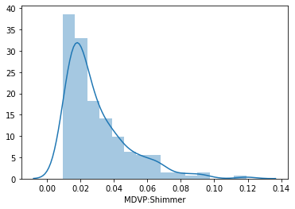

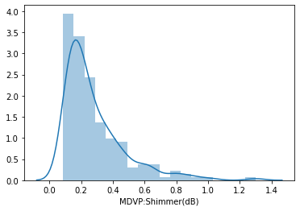

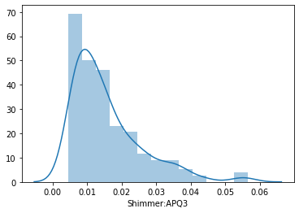

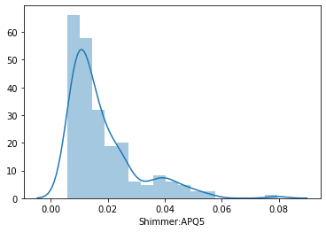

[10 more figures not shown]

```python
for i, col in enumerate(disc_cols[1:-1]):
    plt.figure(i)
    sns.distplot(park_data[col])
```

# Observation:

MDVP:Fo(Hz) --Multimodal distribution

MDVP:Fhi(Hz) --Multimodal distribution

MDVP:Jitter(%) --Right skewed (positive skewness)

MDVP:Jitter(Abs) --Right skewed (positive skewness)

MDVP:RAP --Right skewed (positive skewness)

MDVP:PPQ --Right skewed (positive skewness)

Jitter:DDP --Right skewed (positive skewness)

MDVP:Shimmer --Right skewed (positive skewness)

MDVP:Shimmer(dB) --Right skewed (positive skewness)

Shimmer:APQ3 --Right skewed (positive skewness)

Shimmer:APQ5 --Right skewed (positive skewness)

MDVP:APQ --Right skewed (positive skewness)

Shimmer:DDA --Right skewed (positive skewness)

NHR --Right skewed (positive skewness)

HNR --Multimodal distribution

RPDE --Multimodal distribution

DFA --Multimodal distribution

spread1 --Normally distributed

spread2 --Normally distributed

D2 --Normally distributed

PPE --Normally distributed

```python
park_data.skew()
```

```
MDVP:Fo(Hz)         0.591737
MDVP:Fhi(Hz)        2.542146
MDVP:Flo(Hz)        1.217350
MDVP:Jitter(%)      3.084946
MDVP:Jitter(Abs)    2.649071
MDVP:RAP            3.360708
MDVP:PPQ            3.073892
Jitter:DDP          3.362058
MDVP:Shimmer        1.666480
MDVP:Shimmer(dB)    1.999389
Shimmer:APQ3        1.580576
Shimmer:APQ5        1.798697
MDVP:APQ            2.618047
Shimmer:DDA         1.580618
NHR                 4.220709
HNR                -0.514317
RPDE               -0.143402
DFA                -0.033214
spread1             0.432139
spread2             0.144430
D2                  0.430384
PPE                 0.797491
status             -1.187727
dtype: float64
```

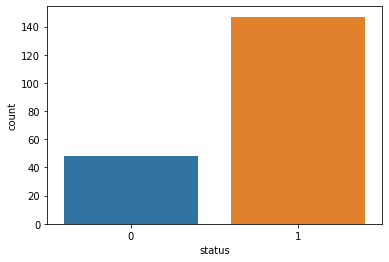

```python
sns.countplot(park_data['status'])
```

```python
park_data.groupby(by="status").count()
```

| status | name | MDVP:Fo(Hz) | MDVP:Fhi(Hz) | MDVP:Flo(Hz) | MDVP:Jitter(%) | MDVP:Jitter(Abs) | MDVP:RAP | MDVP:PPQ | Jitter:DDP | MDVP:Shimmer | ... | MDVP:APQ | Shimmer:DDA | NHR | HNR | RPDE | DFA | spread1 | spread2 | D2 | PPE |
| --- | --- | --- | --- | --- | --- | --- | --- | --- | --- | --- | --- | --- | --- | --- | --- | --- | --- | --- | --- | --- | --- |
| 0 | 48 | 48 | 48 | 48 | 48 | 48 | 48 | 48 | 48 | 48 | ... | 48 | 48 | 48 | 48 | 48 | 48 | 48 | 48 | 48 | 48 |
| 1 | 147 | 147 | 147 | 147 | 147 | 147 | 147 | 147 | 147 | 147 | ... | 147 | 147 | 147 | 147 | 147 | 147 | 147 | 147 | 147 | 147 |

2 rows × 23 columns

# Observation:

**We have more datas with status as 1 and less datas with status as 0. As status being the result parmeter, this may lead to accurate prediction for any data having status as 1 rather than the data having status as 0.**

**Out of 195 records, 147 belong to people having PD.**

**Dataset contains some outliers**

**MDVP:Shimmer has a very high correlation with MDVP:Shimmer(dB), Shimmer:APQ3, Shimmer:APQ5, MDVP:APQ and Shimmer:DDA**

**MDVP:Jitter(%) has a very high correlation with MDVP:Jitter(Abs), MDVP:RAP, MDVP:PPQ and Jitter:DDP**

**Distribution is highly skewed for majority of columns(predictors)**

# 4. Split the dataset into training and test set in the ratio of 70:30 (Training:Test).

**Splitting data into training and test set for independent attributes**

```python
from sklearn.model_selection import train_test_split
from sklearn.preprocessing import StandardScaler

X = park_data.iloc[:,1:-1] # taking all attributes except status and name as independent variable
Y = park_data.iloc[:,-1] # taking status as dependent variable

X_std = StandardScaler().fit_transform(X)

X_train, X_test, y_train, y_test = train_test_split(X_std, Y, test_size=0.3, random_state=1)
```

# 5.Create the model using “entropy” method of reducing the entropy and fit it to training data. (5 points)

**Use decision tree to predict the model. Here let the model grown until all are correctly classified i.e build an overfit model upto the last leaf and maximum depth.**

```python
from sklearn.tree import DecisionTreeClassifier

dt_model = DecisionTreeClassifier(criterion = 'entropy' )
dt_model.fit(X_train, y_train)
```

```
DecisionTreeClassifier(class_weight=None, criterion='entropy', max_depth=None,
                       max_features=None, max_leaf_nodes=None,
                       min_impurity_decrease=0.0, min_impurity_split=None,
                       min_samples_leaf=1, min_samples_split=2,
                       min_weight_fraction_leaf=0.0, presort=False,
                       random_state=None, splitter='best')
```

```python
# display the important features as recognized by the decision tree.
dt_model.fit(X_train,y_train)
feature_importances = dt_model.feature_importances_
feature_names = park_data.columns[0:22]
print("Feature Names are: \n",feature_names)
k = 10
top_k_idx = (feature_importances.argsort()[-k:][::-1])
print(feature_names[top_k_idx], feature_importances)
```

```
Feature Names are:
 Index(['name', 'MDVP:Fo(Hz)', 'MDVP:Fhi(Hz)', 'MDVP:Flo(Hz)', 'MDVP:Jitter(%)',
       'MDVP:Jitter(Abs)', 'MDVP:RAP', 'MDVP:PPQ', 'Jitter:DDP',
       'MDVP:Shimmer', 'MDVP:Shimmer(dB)', 'Shimmer:APQ3', 'Shimmer:APQ5',
       'MDVP:APQ', 'Shimmer:DDA', 'NHR', 'HNR', 'RPDE', 'DFA', 'spread1',
       'spread2', 'D2'],
      dtype='object')
Index(['D2', 'name', 'MDVP:APQ', 'MDVP:Fo(Hz)', 'spread2', 'RPDE',
       'MDVP:Flo(Hz)', 'spread1', 'MDVP:PPQ', 'MDVP:Fhi(Hz)'],
      dtype='object') [0.2191499  0.0998003  0.         0.04073417 0.         0.
 0.         0.         0.         0.         0.         0.
 0.         0.10599956 0.         0.         0.         0.06764433
 0.         0.         0.07940902 0.38726272]
```

# 6.Test the model on test data and what is the accuracy achieved. Capture the predicted values and do a crosstab. (7.5 points)

```python
print("Test: ", dt_model.score(X_test , y_test))
print("Train: ", dt_model.score(X_train , y_train))
```

```
Test:  0.864406779661017
Train:  1.0
```

```python
y_predict = dt_model.predict(X_test)
print(metrics.confusion_matrix(y_test, y_predict))
```

```
[[12  7]
 [ 1 39]]
```

```python
y_predictProbrdtree = dt_model.predict_proba(X_test)

fpr, tpr, thresholds = roc_curve(y_test, y_predictProbrdtree[::,1])

rdt_model_roc = auc(fpr, tpr)

print("ROC:",rdt_model_roc)
```

```
ROC: 0.8032894736842104
```

```python
crosstab = pd.crosstab(y_test.values.flatten(), y_predict,
                          rownames=['Actual'], colnames=['Predicted'],
                          margins=True)
crosstab
```

| Predicted Actual | 0 | 1 | All |
| --- | --- | --- | --- |
| 0 | 12 | 7 | 19 |
| 1 | 1 | 39 | 40 |
| All | 13 | 46 | 59 |

# Observations:

**The accuracy is 0.86**

**Analyzing the confusion matrix**

# True Positives (TP): 39

# True Negatives (TN): 12

# False Positives (FP): 7

# False Negatives (FN): 1

```python
#K-Fold Cross Validation ---this technique is used as number of data points is less
from sklearn.model_selection import cross_val_score, cross_val_predict
scores = cross_val_score(dt_model, X_train,y_train, cv=10)
print("Cross-validated scores:", scores , scores)
print("Average score:" , np.average(scores))
```

```
Cross-validated scores: [0.92857143 0.71428571 1.         0.85714286 1.         0.85714286
 0.85714286 0.76923077 1.         0.91666667] [0.92857143 0.71428571 1.         0.85714286 1.         0.85714286
 0.85714286 0.76923077 1.         0.91666667]
Average score: 0.890018315018315
```

```python
# Print the classification report.
dt_cr=metrics.classification_report(y_test , y_predict)
print(dt_cr)
```

```
              precision    recall  f1-score   support

           0       0.92      0.63      0.75        19
           1       0.85      0.97      0.91        40

    accuracy                           0.86        59
   macro avg       0.89      0.80      0.83        59
weighted avg       0.87      0.86      0.86        59
```

# **Accuracy is 0.86**

**f1-Score and recall is 0.91 and 0.97 respectively for 1 compared to 0.75 and 0.63 for 0**

# 7.Use regularization parameters of max_depth, min_sample_leaf to recreate the model. What is the impact on the model accuracy? How does regularization help? (20 points)

```python
from sklearn.tree import DecisionTreeClassifier
classifier = DecisionTreeClassifier(criterion = 'entropy', random_state = 2, max_depth = 5, min_samples_leaf = 5)
classifier.fit(X_train, y_train)
```

```
DecisionTreeClassifier(class_weight=None, criterion='entropy', max_depth=5,
                       max_features=None, max_leaf_nodes=None,
                       min_impurity_decrease=0.0, min_impurity_split=None,
                       min_samples_leaf=5, min_samples_split=2,
                       min_weight_fraction_leaf=0.0, presort=False,
                       random_state=2, splitter='best')
```

```python
y_predict = classifier.predict(X_test)
print(metrics.confusion_matrix(y_test, y_predict))
```

```
[[14  5]
 [ 1 39]]
```

```python
print("Test score: ", classifier.score(X_test , y_test))
print("Train score: ", classifier.score(X_train , y_train))
```

```
Test score:  0.8983050847457628
Train score:  0.9705882352941176
```

```python
# Print the classification report.

print(metrics.classification_report(y_test, y_predict))
```

```
              precision    recall  f1-score   support

           0       0.93      0.74      0.82        19
           1       0.89      0.97      0.93        40

    accuracy                           0.90        59
   macro avg       0.91      0.86      0.88        59
weighted avg       0.90      0.90      0.89        59
```

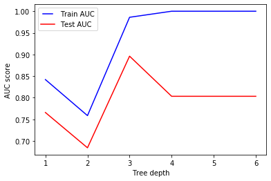

```python
# We are creating a model with max_depth ranging from 1 to 6 and plot the training and test auc scores

max_depths = np.linspace(1, 6, 6, endpoint=True)
train_results = []
test_results = []
for max_depth in max_depths:
    dt = DecisionTreeClassifier(max_depth=max_depth, criterion = 'entropy',random_state = 5)
    dt.fit(X_train,y_train)
    train_pred = dt.predict(X_train)
    false_positive_rate, true_positive_rate, thresholds = roc_curve(y_train, train_pred)
    roc_auc = auc(false_positive_rate, true_positive_rate)
    # Add auc score to previous train results
    train_results.append(roc_auc)
    y_predict = dt.predict(X_test)
    false_positive_rate, true_positive_rate, thresholds = roc_curve(y_test, y_predict)
    roc_auc = auc(false_positive_rate, true_positive_rate)
    # Add auc score to previous test results
    test_results.append(roc_auc)
from matplotlib.legend_handler import HandlerLine2D
line1, = plt.plot(max_depths, train_results, 'b', label="Train AUC")
line2, = plt.plot(max_depths, test_results, 'r', label="Test AUC")
plt.legend(handler_map={line1: HandlerLine2D(numpoints=2)})
plt.ylabel('AUC score')
plt.xlabel('Tree depth')
plt.show()
```

```python
#regularized decisiontree data roc
y_predictProbrdtree = classifier.predict_proba(X_test)

fpr, tpr, thresholds = roc_curve(y_test, y_predictProbrdtree[::,1])

rdt_model_roc = auc(fpr, tpr)

print("ROC:",rdt_model_roc)
```

```
ROC: 0.8756578947368421
```